# Variance in scarid grazing behavior across Caribbean reef sites

Compiled on Fri Mar 12 05:37:18 2021 by Molly Wilson

*Formatted as: Coral Reefs note*

**Mean version**

```r
library(here)
library(tidyverse)
library(R.utils)
library(ggplot2)
library(gridExtra)
library(grid)
library(ggfortify)
library(mgcv)
library(MuMIn)
library(knitr)
library(factoextra)
library(ggthemes)

sum_site <- read.csv(here("data", "site.csv"), strip.white = T, stringsAsFactors = F) %>% select(-X)
sum_id <- read.csv(here("data","sum_id.csv"), stringsAsFactors=F) %>%
  select(-X) %>%
  filter(phase == "i" &
           species_code %in% c("stop","qup") &
           ### size subset 15 - 30cm
           length_cm <= 30 & length_cm >= 15 &
           ### excluding sites with less than 7 observations within size subset range
           !(species_code == "stop" & site == "Pallaster West") &
           !(species_code == "qup" & site %in% c("Pallaster East","Rendezvous","Turtle Bay"))) %>%
  mutate(island = factor(island, levels = c("Bonaire","Antigua","Barbuda"))) %>%
  arrange(island) %>%
  filter(fr <= 3000)

sum_ssp_sub <- sum_id %>%
  group_by(species, species_code, site, island) %>%
  summarize(
    n=n(),
    length_mean=mean(length_cm),
    length_median=median(length_cm),
    length_se=sd(length_cm)/sqrt(n),
    g_frac_mean=mean(g_frac),
    g_frac_median=median(g_frac),
    g_frac_se=sd(g_frac)/sqrt(n),
    br_mean=mean(br,na.rm=TRUE),
    br_median=median(br,na.rm=TRUE),
    br_se=sd(br,na.rm=TRUE)/sqrt(n),
    fr_mean=mean(fr),
    fr_median=median(fr),
    fr_se=sd(fr)/sqrt(n),
    for_dur_mean=mean(for_dur,na.rm=TRUE),
    for_dur_median=median(for_dur,na.rm=TRUE),
    for_dur_se=sd(for_dur,na.rm=TRUE)/sqrt(n),
    for_bites_mean=mean(for_bites,na.rm=TRUE),
    for_bites_median=median(for_bites,na.rm=TRUE),
    for_bites_se=sd(for_bites,na.rm=TRUE)/sqrt(n)
    ) %>%
  left_join(sum_site, by = c("island","site"))
```

## Preliminary investigations

### Sample sizes by site and species

Currently omitting sites with fewer than 7 observations that fall within 15-30cm size subset

```r
sample <- sum_id %>%
  group_by(island, site, species) %>%
  summarize(n=n()) %>%
  arrange(island) %>%
  rename_all(capitalize)
kable(sample)
```

| Island | Site | Species | N |
| --- | --- | --- | --- |
| Bonaire | 18th Palm | Scarus vetula | 26 |
| Bonaire | 18th Palm | Sparisoma viride | 19 |
| Bonaire | Front Porch | Scarus vetula | 18 |
| Bonaire | Front Porch | Sparisoma viride | 20 |
| Bonaire | Karpata | Scarus vetula | 32 |
| Bonaire | Karpata | Sparisoma viride | 20 |
| Bonaire | Oil Slick | Scarus vetula | 32 |
| Bonaire | Oil Slick | Sparisoma viride | 30 |
| Antigua | Mermaid Gardens | Scarus vetula | 13 |
| Antigua | Mermaid Gardens | Sparisoma viride | 12 |
| Antigua | Pillars | Scarus vetula | 9 |
| Antigua | Pillars | Sparisoma viride | 15 |
| Antigua | Rendezvous | Sparisoma viride | 17 |
| Antigua | Snapper Point | Scarus vetula | 8 |
| Antigua | Snapper Point | Sparisoma viride | 10 |
| Antigua | Turtle Bay | Sparisoma viride | 11 |
| Antigua | Windward | Scarus vetula | 7 |
| Antigua | Windward | Sparisoma viride | 11 |
| Barbuda | Pallaster East | Sparisoma viride | 17 |
| Barbuda | Pallaster Mid | Scarus vetula | 8 |
| Barbuda | Pallaster Mid | Sparisoma viride | 12 |
| Barbuda | Pallaster West | Scarus vetula | 10 |

```r
write.csv(sample, file = here("figs/sample.csv"))

sample_vir_sum <- sum_id %>%
  filter(species_code == "stop") %>%
  group_by(site, species, island) %>%
  summarize(n=n()) %>%
  group_by(species) %>%
  summarize(n_sites = n(),
            n_total = sum(n),
            n_mean = mean(n),
            se = sd(n)/sqrt(n_sites))

sample_vet_sum <- sum_id %>%
  filter(species_code == "qup") %>%
  group_by(site, species, island) %>%
  summarize(n=n()) %>%
  group_by(species) %>%
  summarize(n_sites = n(),
            n_total = sum(n),
            n_mean = mean(n),
            se = sd(n)/sqrt(n_sites))
```

### Variable definitions

| Variable | Definition | Unit |
| --- | --- | --- |
| Time spent grazing | Proportion of time spent grazing during follow | fraction |
| Bite rate | Bite rate while actively Grazing | bites/second |
| Feeding rate | Bite rate over total follow time | bites/minute |
| Foray size | Number of consecutive bites taken during single grazing foray | bites/foray |

### Testing parametric assumptions

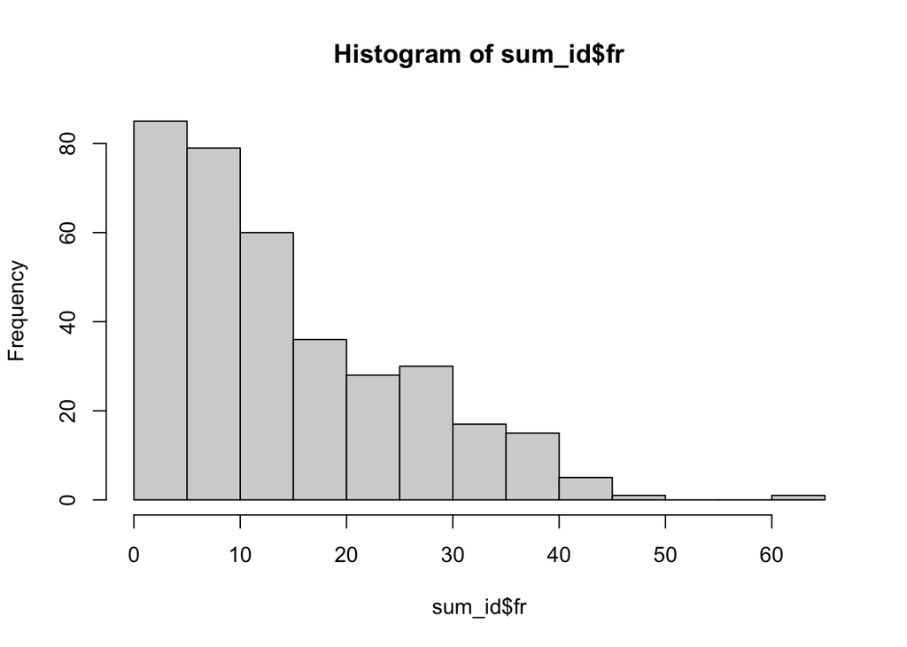

```r
hist(sum_id$fr) # positive skew
```

```r
shapiro.test(sum_id$fr) # non-normal
```

```
##
##  Shapiro-Wilk normality test
##
## data:  sum_id$fr
## W = 0.92437, p-value = 1.891e-12
```

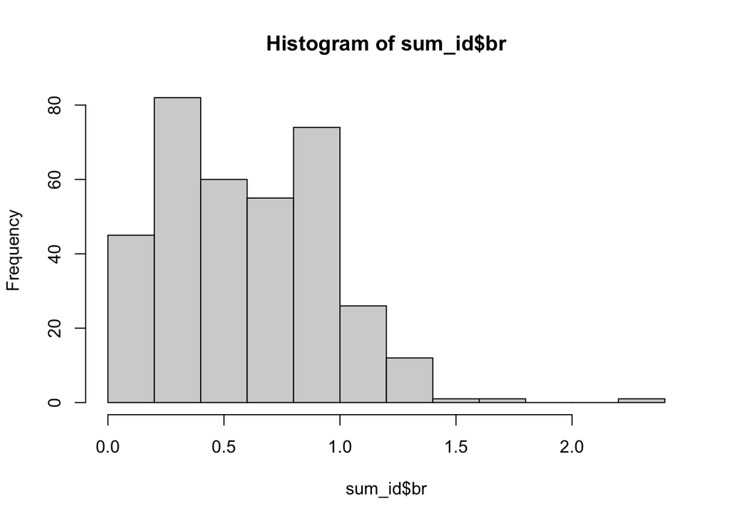

```r
hist(sum_id$br) # positive skew
```

```r
shapiro.test(sum_id$br) # non-normal
```

```
##
##  Shapiro-Wilk normality test
##
## data:  sum_id$br
## W = 0.96581, p-value = 2.029e-07
```

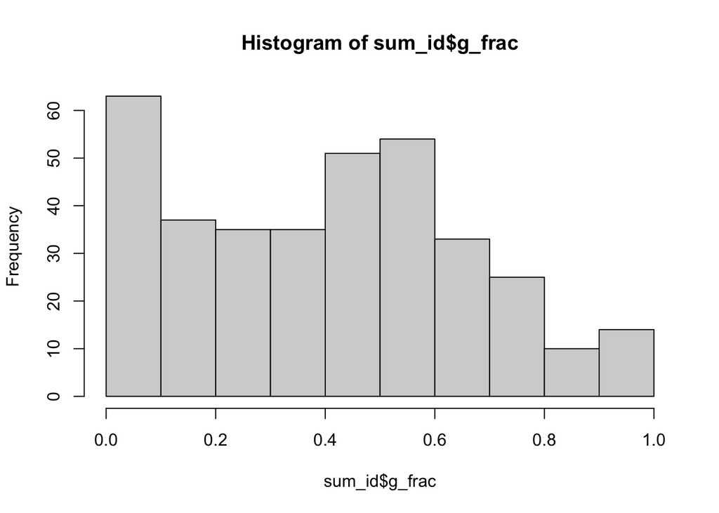

```r
hist(sum_id$g_frac) # positive skew
```

```r
shapiro.test(sum_id$g_frac) # non-normal
```

```
##
##  Shapiro-Wilk normality test
##
## data:  sum_id$g_frac
## W = 0.96445, p-value = 1.248e-07
```

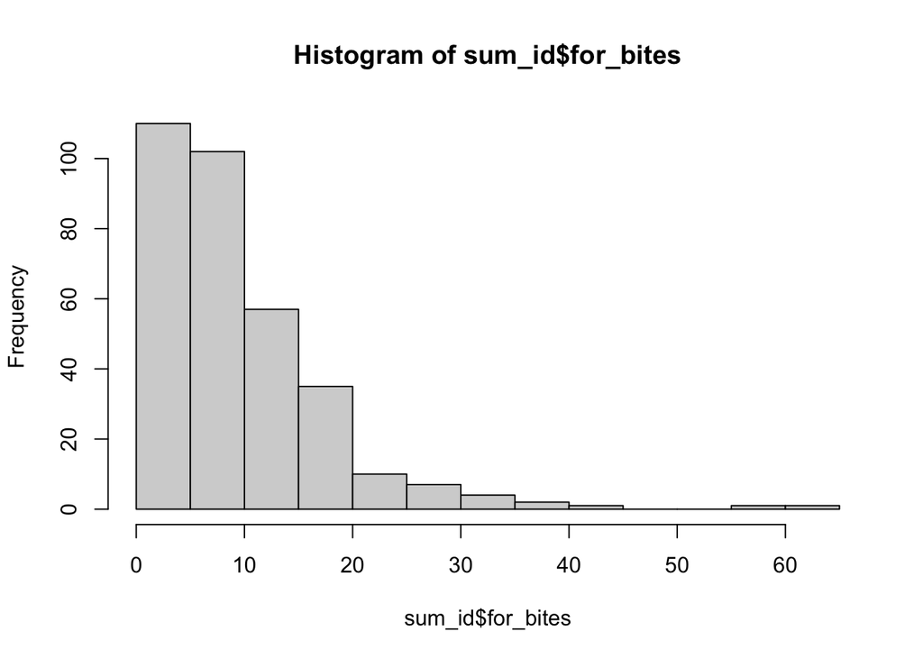

```r
hist(sum_id$for_bites) # positive skew
```

```r
shapiro.test(sum_id$for_bites) # non-normal
```

```
##
##  Shapiro-Wilk normality test
##
## data:  sum_id$for_bites
## W = 0.80023, p-value < 2.2e-16
```

```r
# all positively skewed, non-normally distributed -> should use median, should use Kruskall-Wallis
```

All behavioral variables are positively skewed, non-normally distributed -> should use median values (?) and Kruskall-Wallis instead of ANOVA for site-level differences

## Inter-site differences

Panel graph of behavioral variables across sites:

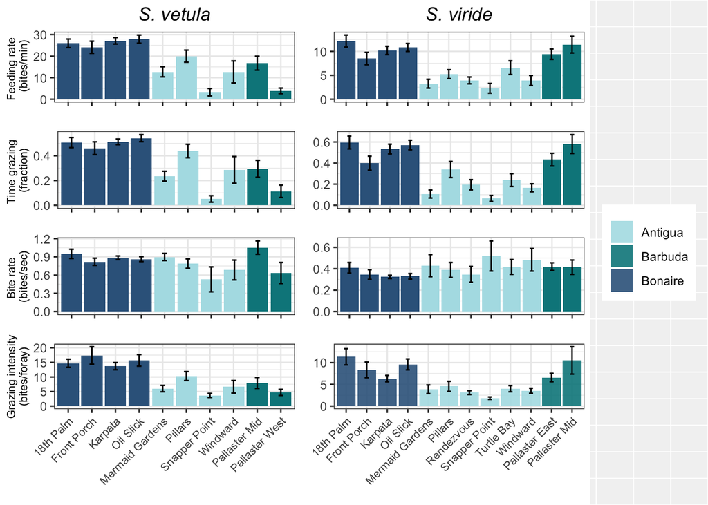

```r
# published Feeding rate (bites/min) for reference lines if needed
# ref_qup15 <- (3329-33*15)/60
# ref_qup30 <- (3329-33*30)/60
# ref_stop15 <- (1089-17*15-56)/60
# ref_stop30 <- (1089-17*30-56)/60

colors <- c("powderblue", "turquoise4", "steelblue4")

fr_qup <-
  ggplot(filter(sum_ssp_sub, species_code == "qup"),
         aes(x=factor(site, levels = sum_site$site), y=fr_mean)) +
  geom_bar(stat = "identity", aes(fill = island), position = "dodge") +
  geom_errorbar(aes(ymin=fr_mean-fr_se, ymax=fr_mean+fr_se), width=.2,
                 position=position_dodge(.9)) +
  scale_fill_manual(values = colors) +
  #geom_abline(slope=0, intercept=ref_qup15,  col = "red",lty=2) +
  #geom_abline(slope=0, intercept=ref_qup25,  col = "red",lty=2) +
  #ylim(0, 50) +
  labs(y = "Feeding rate \n (bites/min)",
       title = "S. vetula") +
  theme_bw() +
  theme(plot.title = element_text(hjust = 0.5, face = "italic"),
        plot.margin = margin(5, 0, 0, 5, unit = "pt"),
        strip.text = element_text(face = "italic"),
        axis.text.x=element_blank(),
        axis.title.x = element_blank(),
        axis.title.y = element_text(size=8),
        legend.position = "none")

fr_stop <-
  ggplot(filter(sum_ssp_sub, species_code == "stop"),
         aes(x=factor(site, levels = sum_site$site), y=fr_mean)) +
  geom_bar(stat = "identity", aes(fill = island), position = "dodge") +
  geom_errorbar(aes(ymin=fr_mean-fr_se, ymax=fr_mean+fr_se), width=.2,
                 position=position_dodge(.9)) +
  scale_fill_manual(values = colors) +
  #geom_abline(slope=0, intercept=ref_stop15,  col = "red",lty=2) +
  #geom_abline(slope=0, intercept=ref_stop25,  col = "red",lty=2) +
  labs(y = "",
       # y = "S. vetula \nFeeding rate (bites/hr)",
       title = "S. viride") +
  theme_bw() +
  theme(plot.title = element_text(hjust = 0.5, face = "italic"),
        plot.margin = margin(5, 4, 0, 0, unit = "pt"),
        strip.text = element_text(face = "italic"),
        axis.text.x=element_blank(),
        axis.title.x = element_blank(),
        legend.position = "none")

br_qup <-
  ggplot(filter(sum_ssp_sub, species_code == "qup"),
         aes(x=factor(site, levels = sum_site$site), y=br_mean)) +
  geom_bar(stat = "identity", aes(fill = island), position = "dodge") +
  geom_errorbar(aes(ymin=br_mean-br_se, ymax=br_mean+br_se), width=.2,
                 position=position_dodge(.9)) +
  scale_fill_manual(values = colors) +
  labs(y = "Bite rate \n(bites/sec)",
       x = "",
       title = "") +
  theme_bw() +
  theme(plot.title = element_text(hjust = 0.5),
        plot.margin = margin(0, 0, 0, 5, unit = "pt"),
        strip.text = element_text(face = "italic"),
        axis.text.x=element_blank(),
        axis.title.x = element_blank(),
        axis.title.y = element_text(size=8),
        legend.position = "none")

br_stop <-
  ggplot(filter(sum_ssp_sub, species_code == "stop"),
         aes(x=factor(site, levels = sum_site$site), y=br_mean)) +
  geom_bar(stat = "identity", aes(fill = island), position = "dodge") +
  geom_errorbar(aes(ymin=br_mean-br_se, ymax=br_mean+br_se), width=.2,
                 position=position_dodge(.9)) +
  scale_fill_manual(values = colors) +
  labs(y = "",
       # y = "S. vetula \nFeeding rate (bites/hr)",
       x = "",
       title = "") +
  theme_bw() +
  theme(plot.title = element_text(hjust = 0.5),
        plot.margin = margin(0, 4, 0, 0, unit = "pt"),
        strip.text = element_text(face = "italic"),
        axis.text.x=element_blank(),
        axis.title.x = element_blank(),
        legend.position = "none")

gfrac_qup <-
  ggplot(filter(sum_ssp_sub, species_code == "qup"),
         aes(x=factor(site, levels = sum_site$site), y=g_frac_mean)) +
  geom_bar(stat = "identity", aes(fill = island), position = "dodge") +
  geom_errorbar(aes(ymin=g_frac_mean-g_frac_se, ymax=g_frac_mean+g_frac_se), width=.2,
                 position=position_dodge(.9)) +
  scale_fill_manual(values = colors) +
  labs(y = "Time grazing \n(fraction)",
       x = "",
       title = "") +
  theme_bw() +
  theme(plot.title = element_text(hjust = 0.5),
        plot.margin = margin(0, 0, 0, 5, unit = "pt"),
        strip.text = element_text(face = "italic"),
        axis.text.x=element_blank(),
        axis.title.x = element_blank(),
        axis.title.y = element_text(size=8),
        legend.position = "none")

gfrac_stop <-
  ggplot(filter(sum_ssp_sub, species_code == "stop"),
         aes(x=factor(site, levels = sum_site$site), y=g_frac_mean)) +
  geom_bar(stat = "identity", aes(fill = island), position = "dodge") +
  geom_errorbar(aes(ymin=g_frac_mean-g_frac_se, ymax=g_frac_mean+g_frac_se), width=.2,
                 position=position_dodge(.9)) +
  scale_fill_manual(values = colors) +
  labs(y = "",
       x = "",
       title = "") +
  theme_bw() +
  theme(plot.title = element_text(hjust = 0.5),
        plot.margin = margin(0, 4, 0, 0, unit = "pt"),
        strip.text = element_text(face = "italic"),
        axis.text.x=element_blank(),
        axis.title.x = element_blank(),
        legend.position = "none")

fi_qup <-
  ggplot(filter(sum_ssp_sub, species_code == "qup"),
         aes(x=factor(site, levels = sum_site$site), y=for_bites_mean)) +
  geom_bar(stat = "identity", aes(fill = island), position = "dodge") +
  geom_errorbar(aes(ymin=for_bites_mean-for_bites_se, ymax=for_bites_mean+for_bites_se), width=.2,
                 position=position_dodge(.9)) +
  scale_fill_manual(values = colors) +
  labs(y = "Grazing intensity\n(bites/foray)",
       x = "",
       title = "") +
  theme_bw() +
  theme(plot.margin = margin(0, 0, 0, 5, unit = "pt"),
        axis.title.y = element_text(size=8),
        axis.text.x = element_text(angle = 45, hjust = 1, size=8),
        legend.position = "none")

fi_stop <-
  ggplot(filter(sum_ssp_sub, species_code == "stop"),
         aes(x=factor(site, levels = sum_site$site), y=for_bites_mean)) +
  geom_bar(stat = "identity", aes(fill = island), alpha = 0.9, position = "dodge") +
  geom_errorbar(aes(ymin=for_bites_mean-for_bites_se, ymax=for_bites_mean+for_bites_se), width=.2,
                 position=position_dodge(.9)) +
  scale_fill_manual(values = colors) +
  labs(y = "",
       x = "",
       title = "") +
  theme_bw() +
  theme(plot.margin = margin(0, 4, 0, 0, unit = "pt"),
        axis.text.x = element_text(angle = 45, hjust = 1, size=8),
        legend.position = "none")

legend_plot <-
  ggplot(filter(sum_ssp_sub, species_code == "stop"),
         aes(x=factor(site, levels = sum_site$site), y=g_frac_mean)) +
  geom_bar(stat = "identity", aes(fill = island), alpha = 0.9, position = "dodge") +
  scale_fill_manual(values = colors) +
  labs(y = "",
       x = "",
       title = "") +
  theme_bw() +
  theme(legend.position = "right",
        legend.title = element_blank())

get_legend<-function(myggplot){
  tmp <- ggplot_gtable(ggplot_build(myggplot))
  leg <- which(sapply(tmp$grobs, function(x) x$name) == "guide-box")
  legend <- tmp$grobs[[leg]]
  return(legend)
  }
legend <- get_legend(legend_plot)

g <- arrangeGrob(
  arrangeGrob(fr_qup, fr_stop, gfrac_qup, gfrac_stop, br_qup, br_stop, fi_qup, fi_stop, ncol=2, heights = c(1,1,1,1.75)),
              arrangeGrob(legend),
              ncol=2, widths = c(5,1))
plot(g)
```

```r
ggsave(here("figs/behavior_panel_means.png"), g, width = 7, height = 7)
```

Testing with violin plots

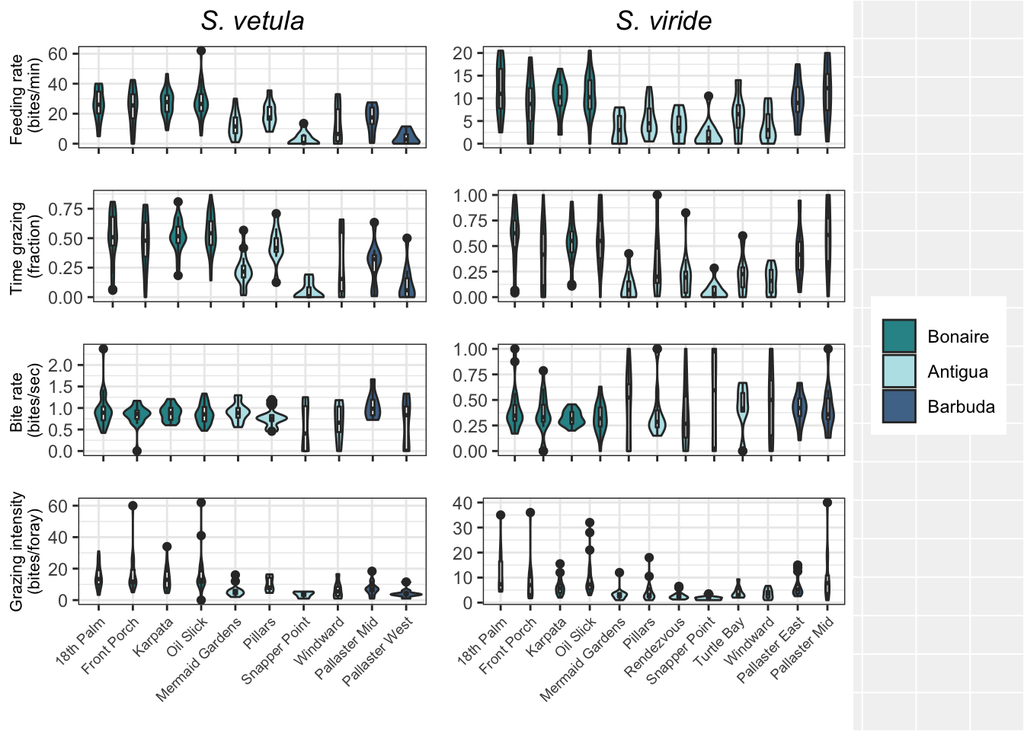

```r
colors <- c("turquoise4", "powderblue", "steelblue4")

fr_qup <-
  ggplot(filter(sum_id, species_code == "qup"),
         aes(x=factor(site, levels = sum_site$site), y=fr)) +
  geom_violin(aes(fill = island), alpha = 0.9) +
  geom_boxplot(width = 0.1) +
  scale_fill_manual(values = colors) +
  labs(y = "Feeding rate \n (bites/min)",
       title = "S. vetula") +
  theme_bw() +
  theme(plot.title = element_text(hjust = 0.5, face = "italic"),
        plot.margin = margin(5, 0, 0, 5, unit = "pt"),
        strip.text = element_text(face = "italic"),
        axis.text.x=element_blank(),
        axis.title.x = element_blank(),
        axis.title.y = element_text(size=8),
        legend.position = "none")

fr_stop <-
  ggplot(filter(sum_id, species_code == "stop"),
         aes(x=factor(site, levels = sum_site$site), y=fr)) +
  geom_violin(aes(fill = island), alpha = 0.9) +
  geom_boxplot(width = 0.1) +
  scale_fill_manual(values = colors) +
  labs(y = "",
       # y = "S. vetula \nFeeding rate (bites/hr)",
       title = "S. viride") +
  theme_bw() +
  theme(plot.title = element_text(hjust = 0.5, face = "italic"),
        plot.margin = margin(5, 4, 0, 0, unit = "pt"),
        strip.text = element_text(face = "italic"),
        axis.text.x=element_blank(),
        axis.title.x = element_blank(),
        legend.position = "none")

br_qup <-
  ggplot(filter(sum_id, species_code == "qup"),
         aes(x=factor(site, levels = sum_site$site), y=br)) +
  geom_violin(aes(fill = island), alpha = 0.9) +
  geom_boxplot(width = 0.1) +
  scale_fill_manual(values = colors) +
  labs(y = "Bite rate \n(bites/sec)",
       x = "",
       title = "") +
  theme_bw() +
  theme(plot.title = element_text(hjust = 0.5),
        plot.margin = margin(0, 0, 0, 5, unit = "pt"),
        strip.text = element_text(face = "italic"),
        axis.text.x=element_blank(),
        axis.title.x = element_blank(),
        axis.title.y = element_text(size=8),
        legend.position = "none")

br_stop <-
  ggplot(filter(sum_id, species_code == "stop"),
         aes(x=factor(site, levels = sum_site$site), y=br)) +
  geom_violin(aes(fill = island), alpha = 0.9) +
  geom_boxplot(width = 0.1) +
  scale_fill_manual(values = colors) +
  labs(y = "",
       # y = "S. vetula \nFeeding rate (bites/hr)",
       x = "",
       title = "") +
  theme_bw() +
  theme(plot.title = element_text(hjust = 0.5),
        plot.margin = margin(0, 4, 0, 0, unit = "pt"),
        strip.text = element_text(face = "italic"),
        axis.text.x=element_blank(),
        axis.title.x = element_blank(),
        legend.position = "none")

gfrac_qup <-
  ggplot(filter(sum_id, species_code == "qup"),
         aes(x=factor(site, levels = sum_site$site), y=g_frac)) +
  geom_violin(aes(fill = island), alpha = 0.9) +
  geom_boxplot(width = 0.1) +
  scale_fill_manual(values = colors) +
  labs(y = "Time grazing \n(fraction)",
       x = "",
       title = "") +
  theme_bw() +
  theme(plot.title = element_text(hjust = 0.5),
        plot.margin = margin(0, 0, 0, 5, unit = "pt"),
        strip.text = element_text(face = "italic"),
        axis.text.x=element_blank(),
        axis.title.x = element_blank(),
        axis.title.y = element_text(size=8),
        legend.position = "none")

gfrac_stop <-
  ggplot(filter(sum_id, species_code == "stop"),
         aes(x=factor(site, levels = sum_site$site), y=g_frac)) +
  geom_violin(aes(fill = island), alpha = 0.9) +
  geom_boxplot(width = 0.1) +
  scale_fill_manual(values = colors) +
  labs(y = "",
       x = "",
       title = "") +
  theme_bw() +
  theme(plot.title = element_text(hjust = 0.5),
        plot.margin = margin(0, 4, 0, 0, unit = "pt"),
        strip.text = element_text(face = "italic"),
        axis.text.x=element_blank(),
        axis.title.x = element_blank(),
        legend.position = "none")

fi_qup <-
  ggplot(filter(sum_id, species_code == "qup"),
         aes(x=factor(site, levels = sum_site$site), y=for_bites)) +
  geom_violin(aes(fill = island), alpha = 0.9) +
  geom_boxplot(width = 0.1) +
  scale_fill_manual(values = colors) +
  labs(y = "Grazing intensity\n(bites/foray)",
       x = "",
       title = "") +
  theme_bw() +
  theme(plot.margin = margin(0, 0, 0, 5, unit = "pt"),
        axis.title.y = element_text(size=8),
        axis.text.x = element_text(angle = 45, hjust = 1, size=7),
        legend.position = "none")

fi_stop <-
  ggplot(filter(sum_id, species_code == "stop"),
         aes(x=factor(site, levels = sum_site$site), y=for_bites)) +
  geom_violin(aes(fill = island), alpha = 0.9) +
  geom_boxplot(width = 0.1) +
  scale_fill_manual(values = colors) +
  labs(y = "",
       x = "",
       title = "") +
  theme_bw() +
  theme(plot.margin = margin(0, 4, 0, 0, unit = "pt"),
        axis.text.x = element_text(angle = 45, hjust = 1, size=7),
        legend.position = "none")

legend_plot <-
  ggplot(filter(sum_id, species_code == "stop"),
         aes(x=factor(site, levels = sum_site$site), y=g_frac)) +
  geom_violin(aes(fill = island), alpha = 0.9) +
  geom_boxplot(width = 0.1) +
  scale_fill_manual(values = colors) +
  labs(y = "",
       x = "",
       title = "") +
  theme_bw() +
  theme(legend.position = "right",
        legend.title = element_blank())

get_legend<-function(myggplot){
  tmp <- ggplot_gtable(ggplot_build(myggplot))
  leg <- which(sapply(tmp$grobs, function(x) x$name) == "guide-box")
  legend <- tmp$grobs[[leg]]
  return(legend)
  }
legend <- get_legend(legend_plot)

g <- arrangeGrob(
  arrangeGrob(fr_qup, fr_stop, gfrac_qup, gfrac_stop, br_qup, br_stop, fi_qup, fi_stop, ncol=2, heights = c(1,1,1,1.75)),
              arrangeGrob(legend),
              ncol=2, widths = c(5,1))
plot(g)
```

```r
ggsave(here("figs/behavior_panel_violin.png"), g, width = 8, height = 8)
```

Kruskal-Wallis tests to look at significance of inter-site variance for different behavioral variables:

Feeding rate:

```r
vir <- sum_id %>% filter(species_code == "stop")
vet <- sum_id %>% filter(species_code == "qup")

kruskal.test(fr ~ site, data = vet) # p<0.001
```

```
##
##  Kruskal-Wallis rank sum test
##
## data:  fr by site
## Kruskal-Wallis chi-squared = 64.431, df = 9, p-value = 1.861e-10
```

```r
kruskal.test(fr ~ site, data = vir) # p<0.001
```

```
##
##  Kruskal-Wallis rank sum test
##
## data:  fr by site
## Kruskal-Wallis chi-squared = 70.913, df = 11, p-value = 8.19e-11
```

Bite rate:

```r
kruskal.test(br ~ site, data = vet) # p>0.5 (p=0.63)
```

```
##
##  Kruskal-Wallis rank sum test
##
## data:  br by site
## Kruskal-Wallis chi-squared = 7.1086, df = 9, p-value = 0.6258
```

```r
kruskal.test(br ~ site, data = vir) # p>0.5 (p=0.55)
```

```
##
##  Kruskal-Wallis rank sum test
##
## data:  br by site
## Kruskal-Wallis chi-squared = 9.772, df = 11, p-value = 0.551
```

Fraction of time grazing:

```r
kruskal.test(g_frac ~ site, data = vet) # p<0.001
```

```
##
##  Kruskal-Wallis rank sum test
##
## data:  g_frac by site
## Kruskal-Wallis chi-squared = 61.308, df = 9, p-value = 7.498e-10
```

```r
kruskal.test(g_frac ~ site, data = vir) # p<0.001
```

```
##
##  Kruskal-Wallis rank sum test
##
## data:  g_frac by site
## Kruskal-Wallis chi-squared = 77.735, df = 11, p-value = 4.038e-12
```

Grazing intensity:

```r
kruskal.test(for_bites ~ site, data = vet) # p<0.001
```

```
##
##  Kruskal-Wallis rank sum test
##
## data:  for_bites by site
## Kruskal-Wallis chi-squared = 48.983, df = 9, p-value = 1.672e-07
```

```r
kruskal.test(for_bites ~ site, data = vir) # p<0.001
```

```
##
##  Kruskal-Wallis rank sum test
##
## data:  for_bites by site
## Kruskal-Wallis chi-squared = 63.447, df = 11, p-value = 2.108e-09
```

## Loess plots of various drivers

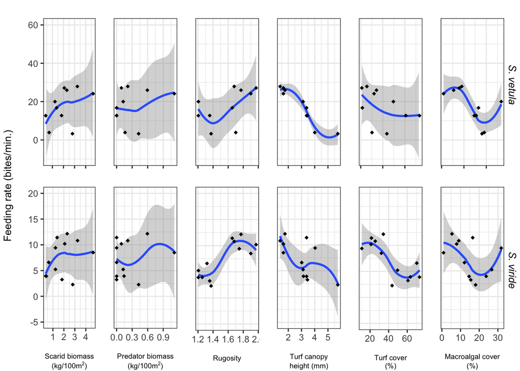

```r
fr_q1 <- ggplot(filter(sum_ssp_sub, species_code == "qup"), aes(x = scar_bm/1000, y = fr_mean)) +
  geom_smooth(method="loess", span=1) +
  geom_point(shape=18) +
  ylim(-10, 60) +
  labs(y = "",
       title = "") +
  theme_bw() +
  theme(plot.title = element_text(hjust = 0.5),
        plot.margin = margin(0, 1, 0, 0, unit = "pt"),
        axis.text.x = element_blank(),
        axis.title.x = element_blank()
        )

fr_q2 <- ggplot(filter(sum_ssp_sub, species_code == "qup"), aes(x = carn30_bm/1000, y = fr_mean)) +
  geom_smooth(method="loess", span=1) +
  geom_point(shape=18) +
  ylim(-10, 60) +
  labs(y = "",
       title = "") +
  theme_bw() +
  theme(plot.title = element_text(hjust = 0.5),
        axis.ticks.y = element_blank(),
        axis.text.y = element_blank(),
        plot.margin = margin(0, 1, 0, 1, unit = "pt"),
        axis.text.x = element_blank(),
        axis.title.x = element_blank()
        )

fr_q3 <- ggplot(filter(sum_ssp_sub, species_code == "qup"), aes(x = rugosity, y = fr_mean)) +
  geom_smooth(method="loess", span=1) +
  geom_point(shape=18) +
  ylim(-10, 60) +
  labs(y = "",
       title = "") +
  theme_bw() +
  theme(plot.title = element_text(hjust = 0.5),
        axis.ticks.y = element_blank(),
        axis.text.y = element_blank(),
        plot.margin = margin(0, 1, 0, 1, unit = "pt"),
        axis.text.x = element_blank(),
        axis.title.x = element_blank()
        )

fr_q4 <- ggplot(filter(sum_ssp_sub, species_code == "qup"), aes(x = ta_canopy, y = fr_mean)) +
  geom_smooth(method="loess", span=1) +
  geom_point(shape=18) +
  ylim(-10, 60) +
  labs(y = "",
       title = "") +
  theme_bw() +
  theme(plot.title = element_text(hjust = 0.5),
        axis.ticks.y = element_blank(),
        axis.text.y = element_blank(),
        plot.margin = margin(0, 1, 0, 1, unit = "pt"),
        axis.text.x = element_blank(),
        axis.title.x = element_blank()
        )

fr_q5 <- ggplot(filter(sum_ssp_sub, species_code == "qup"), aes(x = ta_cover, y = fr_mean)) +
  geom_smooth(method="loess", span=1) +
  geom_point(shape=18) +
  ylim(-10, 60) +
  labs(y = "",
       title = "") +
  theme_bw() +
  theme(plot.title = element_text(hjust = 0.5),
        axis.ticks.y = element_blank(),
        axis.text.y = element_blank(),
        plot.margin = margin(0, 1, 0, 1, unit = "pt"),
        axis.text.x = element_blank(),
        axis.title.x = element_blank()
        )

fr_q7 <- ggplot(filter(sum_ssp_sub, species_code == "qup"), aes(x = ma_cover, y = fr_mean)) +
  geom_smooth(method="loess", span=1) +
  geom_point(shape=18) +
  ylim(-10, 60) +
  labs(y = "",
       title = "") +
  theme_bw() +
  theme(plot.title = element_text(hjust = 0.5),
        axis.ticks.y = element_blank(),
        axis.text.y = element_blank(),
        plot.margin = margin(0, 1, 0, 1, unit = "pt"),
        axis.text.x = element_blank(),
        axis.title.x = element_blank()
        )

fr_s1 <- ggplot(filter(sum_ssp_sub, species_code == "stop"), aes(x = scar_bm/1000, y = fr_mean)) +
  geom_smooth(method="loess", span=1) +
  geom_point(shape=18) +
  ylim(-5, 20) +
  labs(y = "",
       x = expression(atop(NA, atop(textstyle('Scarid biomass'),
                               textstyle('(kg/100m'^2*')')))),
       title = "") +
  theme_bw() +
  theme(plot.title = element_text(hjust = 0.5),
        plot.margin = margin(0, 1, 0, 0, unit = "pt"),
        axis.title.x = element_text(size = 7)
        )

fr_s2 <- ggplot(filter(sum_ssp_sub, species_code == "stop"), aes(x = carn30_bm/1000, y = fr_mean)) +
  geom_smooth(method="loess", span=1) +
  geom_point(shape=18) +
  ylim(-5, 20) +
  labs(y = "",
       x = expression(atop(NA, atop(textstyle('Predator biomass'),
                               textstyle('(kg/100m'^2*')')))),
       title = "") +
  theme_bw() +
  theme(plot.title = element_text(hjust = 0.5),
        axis.ticks.y = element_blank(),
        axis.text.y = element_blank(),
        axis.title.x = element_text(size = 7),
        plot.margin = margin(0, 1, 0, 1, unit = "pt")
        )

fr_s3 <- ggplot(filter(sum_ssp_sub, species_code == "stop"), aes(x = rugosity, y = fr_mean)) +
  geom_smooth(method="loess", span=1) +
  geom_point(shape=18) +
  ylim(-5, 20) +
  labs(y = "",
       x = expression(atop(NA, atop(textstyle('Rugosity'),
                               textstyle('  ')))),
       title = "") +
  theme_bw() +
  theme(plot.title = element_text(hjust = 0.5),
        axis.ticks.y = element_blank(),
        axis.text.y = element_blank(),
        axis.title.x = element_text(size = 7),
        plot.margin = margin(0, 1, 0, 1, unit = "pt")
        )

fr_s4 <- ggplot(filter(sum_ssp_sub, species_code == "stop"), aes(x = ta_canopy, y = fr_mean)) +
  geom_smooth(method="loess", span=1) +
  geom_point(shape=18) +
  ylim(-5, 20) +
  labs(y = "",
       x = expression(atop(NA, atop(textstyle('Turf canopy'),
                               textstyle('height (mm)')))),
       title = "") +
  theme_bw() +
  theme(plot.title = element_text(hjust = 0.5),
        axis.ticks.y = element_blank(),
        axis.text.y = element_blank(),
        axis.title.x = element_text(size = 7),
        plot.margin = margin(0, 1, 0, 1, unit = "pt")
        )

fr_s5 <- ggplot(filter(sum_ssp_sub, species_code == "stop"), aes(x = ta_cover, y = fr_mean)) +
  geom_smooth(method="loess", span=1) +
  geom_point(shape=18) +
  ylim(-5, 20) +
  labs(y = "",
       x = expression(atop(NA, atop(textstyle('Turf cover'),
                               textstyle('(%)')))),
       title = "") +
  theme_bw() +
  theme(plot.title = element_text(hjust = 0.5),
        axis.ticks.y = element_blank(),
        axis.text.y = element_blank(),
        axis.title.x = element_text(size = 7),
        plot.margin = margin(0, 1, 0, 1, unit = "pt")
        )

fr_s7 <- ggplot(filter(sum_ssp_sub, species_code == "stop"), aes(x = ma_cover, y = fr_mean)) +
  geom_smooth(method="loess", span=1) +
  geom_point(shape=18) +
  ylim(-5, 20) +
  labs(y = "",
       x = expression(atop(NA, atop(textstyle('Macroalgal cover'),
                               textstyle('(%)')))),
       title = "") +
  theme_bw() +
  theme(plot.title = element_text(hjust = 0.5),
        axis.title.x = element_text(size = 7),
        axis.ticks.y = element_blank(),
        axis.text.y = element_blank(),
        plot.margin = margin(0, 1, 0, 1, unit = "pt")
        )

label_vet = textGrob("S. vetula", gp=gpar(fontface="italic", fontsize = 10), rot=270)
label_vir = textGrob("S. viride", gp=gpar(fontface="italic", fontsize = 10), rot=270)

g <- grid.arrange(left = textGrob("Feeding rate (bites/min.)", rot = 90, gp = gpar(fontsize = 10)),
  arrangeGrob(fr_q1, fr_q2, fr_q3, fr_q4, fr_q5, fr_q7, ncol=6, right = label_vet),
  arrangeGrob(fr_s1, fr_s2, fr_s3, fr_s4, fr_s5, fr_s7, ncol=6, right = label_vir),
  nrow=2, heights = c(1,1.2))
```

```r
ggsave(here("figs/biplot_panel_means.png"), g, width = 7, height = 4)
```

### Carnivore Loess for supplement

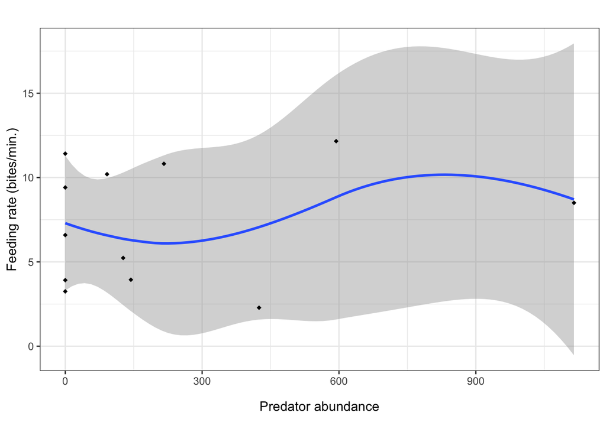

```r
ggplot(filter(sum_ssp_sub, species_code == "stop"), aes(x = carn30_bm, y = fr_mean)) +
  geom_smooth(method="loess", span=1) +
  geom_point(shape=18) +
  labs(y = "Feeding rate (bites/min.)",
       x = expression(atop(NA, atop(textstyle('Predator abundance')))),
       title = "") +
  theme_bw() +
  theme(plot.title = element_text(hjust = 0.5)
        )
```

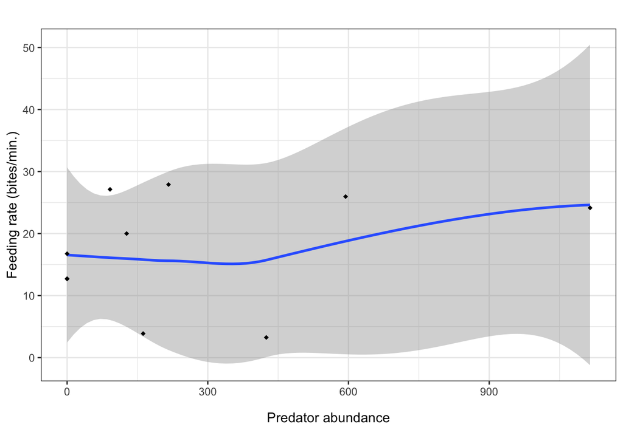

```r
ggplot(filter(sum_ssp_sub, species_code == "qup"), aes(x = carn30_bm, y = fr_mean)) +
  geom_smooth(method="loess", span=1) +
  geom_point(shape=18) +
  labs(y = "Feeding rate (bites/min.)",
       x = expression(atop(NA, atop(textstyle('Predator abundance')))),
       title = "") +
  theme_bw() +
  theme(plot.title = element_text(hjust = 0.5)
        )
```

## PCA

```r
pca_data <- na.omit(sum_site %>%
  select(rugosity, ma_cover, ma_canopy, ta_cover, ta_canopy, lc_cover, scar_bm, scar_den, carn30_bm))
names(pca_data)[1:9] =
  c("rugosity", "macroalgal cover", "macroalgal canopy", "turf cover", "turf canopy", "coral cover", "scarid biomass", "scarid density", "predator biomass")

pca_pred <- prcomp(pca_data, center = T, scale = T)
print(pca_pred)
```

```
## Standard deviations (1, .., p=9):
## [1] 2.2377426 1.4836691 0.9615838 0.5833895 0.4901210 0.3928401 0.3171249
## [8] 0.1450207 0.1005302
##
## Rotation (n x k) = (9 x 9):
##                          PC1         PC2         PC3        PC4         PC5
## rugosity          -0.3696538  0.34072403 -0.12329866  0.1134347 -0.12210843
## macroalgal cover   0.3550425  0.29245420  0.06604267 -0.6242821 -0.36910486
## macroalgal canopy  0.3496908  0.33465663 -0.02151066 -0.2157453  0.49993421
## turf cover         0.2500668 -0.54040144  0.01586495  0.2729311  0.09735420
## turf canopy        0.3168875  0.20369824  0.57979272  0.3682139  0.13998160
## coral cover       -0.4114486 -0.05984824 -0.28602882 -0.1832267  0.23234268
## scarid biomass    -0.3679643 -0.03578035  0.45273426 -0.3212215  0.57497330
## scarid density    -0.2070910  0.56494937  0.03658562  0.4258421 -0.05600155
## predator biomass  -0.3232520 -0.16978249  0.59618999 -0.1506278 -0.42676767
##                           PC6         PC7         PC8         PC9
## rugosity           0.27180005 -0.42471112  0.61239743 -0.27385639
## macroalgal cover  -0.22430212 -0.02110411  0.33145679  0.31219660
## macroalgal canopy  0.63040489 -0.16231350 -0.18926691  0.09591865
## turf cover         0.22617682 -0.05763872  0.50683330  0.49985379
## turf canopy       -0.37315009 -0.47425933 -0.02793392 -0.04254713
## coral cover       -0.27670941 -0.53743947 -0.22177891  0.49311812
## scarid biomass    -0.14420601  0.30997766  0.32625646 -0.03537498
## scarid density     0.02225204  0.39783008 -0.01384837  0.54145510
## predator biomass   0.43605894 -0.14625038 -0.25652015  0.17053154
```

```r
pca_var <- get_pca_var(pca_pred)
print(pca_var$contrib)
```

```
##                       Dim.1      Dim.2       Dim.3     Dim.4      Dim.5
## rugosity          13.664393 11.6092866  1.52025603  1.286744  1.4910469
## macroalgal cover  12.605518  8.5529458  0.43616343 38.972819 13.6238395
## macroalgal canopy 12.228363 11.1995058  0.04627085  4.654604 24.9934213
## turf cover         6.253340 29.2033718  0.02516965  7.449136  0.9477841
## turf canopy       10.041768  4.1492973 33.61595959 13.558144  1.9594849
## coral cover       16.928992  0.3581812  8.18124839  3.357202  5.3983121
## scarid biomass    13.539771  0.1280233 20.49683065 10.318326 33.0594298
## scarid density     4.288669 31.9167787  0.13385074 18.134152  0.3136174
## predator biomass  10.449186  2.8826096 35.54425067  2.268874 18.2130640
##                         Dim.6       Dim.7       Dim.8      Dim.9
## rugosity           7.38752666 18.03795359 37.50306072  7.4997323
## macroalgal cover   5.03114430  0.04453836 10.98636024  9.7466715
## macroalgal canopy 39.74103281  2.63456708  3.58219638  0.9200387
## turf cover         5.11559561  0.33222219 25.68799946 24.9853815
## turf canopy       13.92409884 22.49219087  0.07803037  0.1810258
## coral cover        7.65680958 28.88411863  4.91858852 24.3165478
## scarid biomass     2.07953740  9.60861495 10.64432765  0.1251389
## scarid density     0.04951532 15.82687695  0.01917773 29.3173628
## predator biomass  19.01473949  2.13891737  6.58025893  2.9081008
```

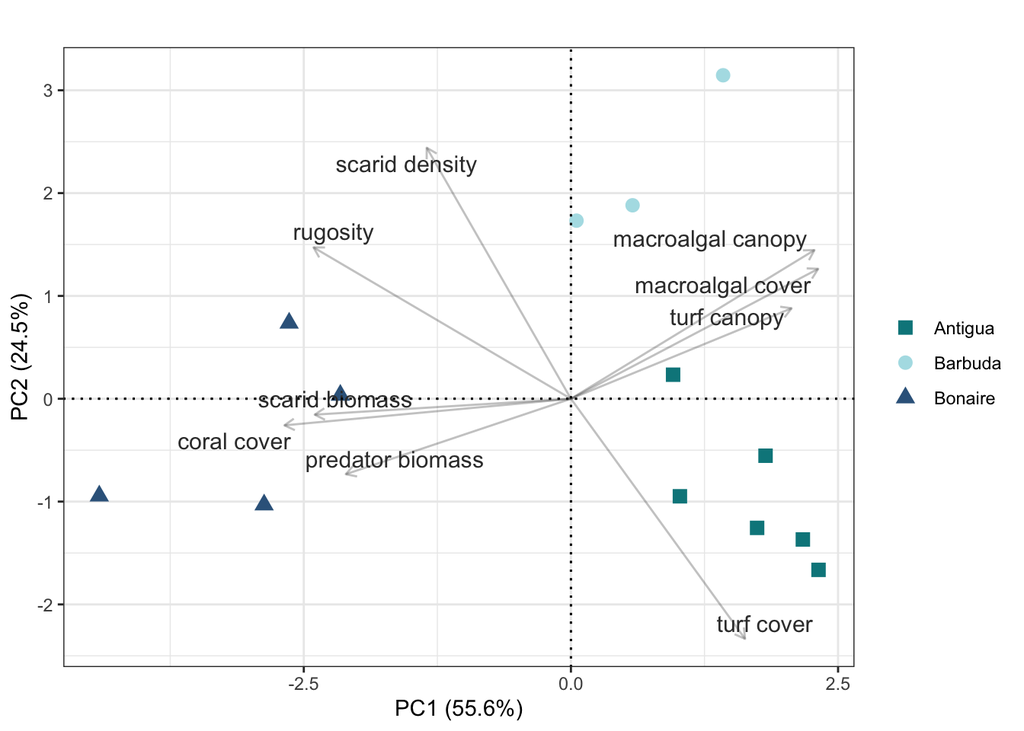

```r
set.seed(5)
fviz_pca_biplot(pca_pred,
                col.ind = sum_site$island,
                mean.point = F,
                label = "var",
                repel = T,
                pointsize = 3,
                alpha.var= 0.3,
                col.var = "gray22",
                labelsize = 4,
                axes.linetype = "dotted"
                ) +
  scale_shape_manual(values = c(15,16,17)) +
  scale_color_manual(values = colors) +
  labs(x = "PC1 (55.6%)", y = "PC2 (24.5%)", title = "") +
  theme_bw() +
  theme(legend.title = element_blank())
```

```r
ggsave(here("figs/pca_pred.png"), width = 7, height = 5)
```

```r
sum_site_pca <- sum_site %>%
  bind_cols(as.data.frame(pca_pred$x) %>%
           select(PC1,PC2)) %>%
  rename(pc1_all=PC1,
         pc2_all=PC2)

sum_id_pca <- sum_id %>%
  left_join(select(sum_site_pca,site,pc1_all,pc2_all), by = "site")
sum_ssp_pca <- sum_ssp_sub %>%
  left_join(select(sum_site_pca,site,pc1_all,pc2_all), by = "site")
```

## GAMM results

Note that these GAMMs are using the size subsetted data, as opposed to the full size ranges

Predicting feeding rate (site-level means, island as random effect)

```r
m_data <- sum_ssp_pca

# gamm1 <- gamm(fr_mean ~ species_code + s(length_mean, k=3) + s(pc1_all, k=3) + s(pc2_all, k=3),
#            family = gaussian(link=identity),
#            random = list(island=~1),
#            data = m_data
#            )
# g1 <- c("g1", "Species + Size + PC1 + PC2", AICc(gamm1$lme), summary(gamm1$gam)$r.sq)

gamm2 <- gamm(fr_mean ~ species_code + s(length_mean, k=3) + s(pc1_all, k=3),
           family = gaussian(link=identity),
           random = list(island=~1),
           data = m_data
           )
g2 <- c("g2", "Species + Size + PC1", AICc(gamm2$lme), summary(gamm2$gam)$r.sq)

# gamm3 <- gamm(fr_mean ~ species_code + s(length_mean, by = factor(species_code), k=3) + s(pc1_all, by = factor(species_code), k=3) + s(pc2_all, by = factor(species_code), k=3),
#            family = gaussian(link=identity),
#            random = list(island=~1),
#            data = m_data
#            )
# g3 <- c("g3", "Species + Size~Species + PC1~Species + PC2~Species", AICc(gamm3$lme), summary(gamm3$gam)$r.sq)

# gamm4 <- gamm(fr_mean ~ species_code + s(length_mean, by = factor(species_code), k=3) + s(pc1_all, by = factor(species_code), k=3) + s(pc2_all, k=3),
#            family = gaussian(link=identity),
#            random = list(island=~1),
#            data = m_data
#            )
# g4 <- c("g4", "Species + Size~Species + PC1~Species + PC2", AICc(gamm4$lme), summary(gamm4$gam)$r.sq)

gamm5 <- gamm(fr_mean ~ species + s(length_mean, by = factor(species_code), k=3) + s(pc1_all, by = factor(species_code), k=3),
           family = gaussian(link=identity),
           random = list(island=~1),
           data = m_data
           )
g5 <- c("g5", "Species + Size~Species + PC1~Species", AICc(gamm5$lme), summary(gamm5$gam)$r.sq)

gamm6 <- gamm(fr_mean ~ s(length_mean, k=3) + s(pc1_all, by = factor(species_code), k=3),
           family = gaussian(link=identity),
           random = list(island=~1),
           data = m_data
           )
g6 <- c("g6", "Size + PC1~Species", AICc(gamm6$lme), summary(gamm6$gam)$r.sq)

gamm7 <- gamm(fr_mean ~ s(length_mean, by = factor(species_code), k=3) + s(pc1_all, k=3),
           family = gaussian(link=identity),
           random = list(island=~1),
           data = m_data
           )
g7 <- c("g7", "Size~Species + PC1", AICc(gamm7$lme), summary(gamm7$gam)$r.sq)

gamm8 <- gamm(fr_mean ~ species + s(length_mean, by = factor(species_code), k=3) + s(pc1_all, k=3),
           family = gaussian(link=identity),
           random = list(island=~1),
           data = m_data
           )
g8 <- c("g8", "Species + Size~Species + PC1", AICc(gamm8$lme), summary(gamm8$gam)$r.sq)

gamm9 <- gamm(fr_mean ~ species + s(length_mean, k=3) + s(pc1_all, by = factor(species_code), k=3),
           family = gaussian(link=identity),
           random = list(island=~1),
           data = m_data
           )
g9 <- c("g9", "Species + Size + PC1~Species", AICc(gamm9$lme), summary(gamm9$gam)$r.sq)

gamm10 <- gamm(fr_mean ~ species + s(pc1_all, by = factor(species_code), k=3),
           family = gaussian(link=identity),
           random = list(island=~1),
           data = m_data
           )
g10 <- c("g10", "Species + PC1~Species", AICc(gamm10$lme), summary(gamm10$gam)$r.sq)

gamm11 <- gamm(fr_mean ~ s(length_mean, by = factor(species_code), k=3) + s(pc1_all, by = factor(species_code), k=3),
           family = gaussian(link=identity),
           random = list(island=~1),
           data = m_data
           )
g11 <- c("g11", "Size~Species + PC1~Species", AICc(gamm11$lme), summary(gamm11$gam)$r.sq)

gamm12 <- gamm(fr_mean ~ species_code + s(pc1_all, k=3),
           family = gaussian(link=identity),
           random = list(island=~1),
           data = m_data
           )
g12 <- c("g12", "Species + PC1", AICc(gamm12$lme), summary(gamm12$gam)$r.sq)


gtab_fr_site <- as.data.frame(rbind(g2,g5,g6,g7,g8,g9,g10,g11,g12)) %>% setNames(c("g","Model", "AICc", "Adj. R2")) %>% arrange(AICc)
kable(gtab_fr_site)
```

|  | g | Model | AICc | Adj. R2 |
| --- | --- | --- | --- | --- |
| g12 | g12 | Species + PC1 | 150.42062908976 | 0.590052686807725 |
| g10 | g10 | Species + PC1~Species | 155.955633522003 | 0.638262884757218 |
| g2 | g2 | Species + Size + PC1 | 159.844620283629 | 0.568317711894194 |
| g9 | g9 | Species + Size + PC1~Species | 168.873006966034 | 0.617083514456803 |
| g8 | g8 | Species + Size~Species + PC1 | 170.085839715251 | 0.595381084867312 |
| g6 | g6 | Size + PC1~Species | 177.126739179657 | 0.276565535752374 |
| g7 | g7 | Size~Species + PC1 | 177.814252885715 | 0.253600794361869 |
| g5 | g5 | Species + Size~Species + PC1~Species | 186.146431839912 | 0.626272289245872 |
| g11 | g11 | Size~Species + PC1~Species | 191.80080412162 | 0.292753948262639 |

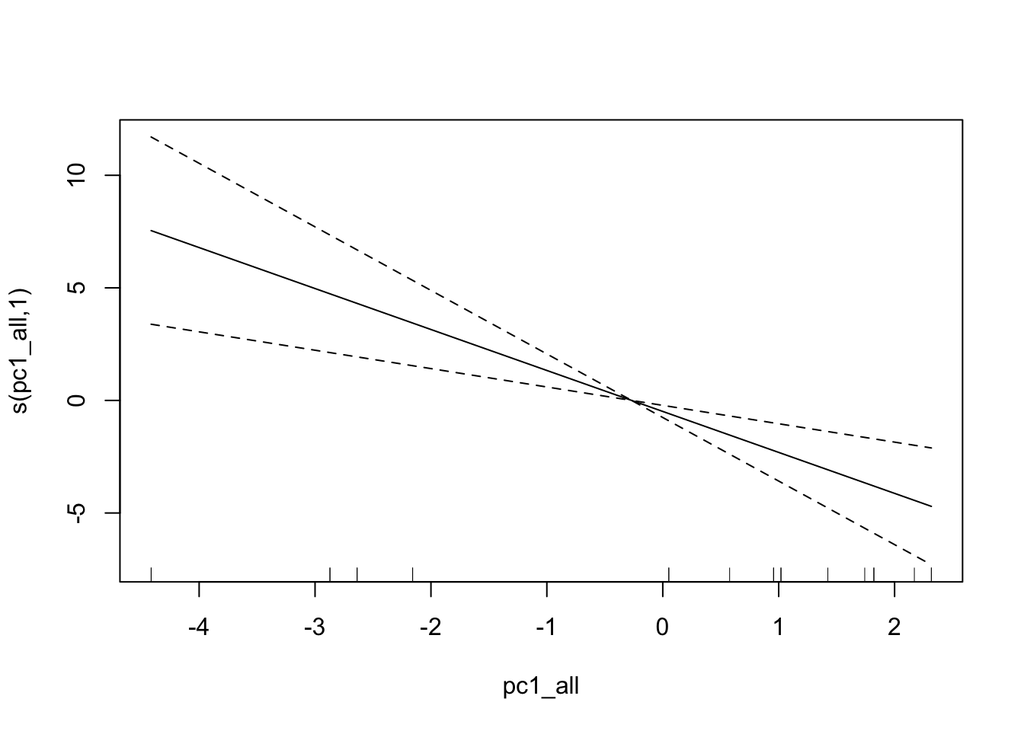

```r
# summary + plots from best models
plot(gamm12$gam,pages=1)
```

```r
summary(gamm12$gam)
```

```
##
## Family: gaussian
## Link function: identity
##
## Formula:
## fr_mean ~ species_code + s(pc1_all, k = 3)
##
## Parametric coefficients:
##                  Estimate Std. Error t value Pr(>|t|)
## (Intercept)        16.960      1.648  10.294  3.3e-09 ***
## species_codestop   -9.248      2.237  -4.134 0.000564 ***
## ---
## Signif. codes:  0 '***' 0.001 '**' 0.01 '*' 0.05 '.' 0.1 ' ' 1
##
## Approximate significance of smooth terms:
##            edf Ref.df     F p-value
## s(pc1_all)   1      1 13.16 0.00169 **
## ---
## Signif. codes:  0 '***' 0.001 '**' 0.01 '*' 0.05 '.' 0.1 ' ' 1
##
## R-sq.(adj) =   0.59
##   Scale est. = 24.518    n = 22
```

```r
summary(gamm10$gam)
```

```
##
## Family: gaussian
## Link function: identity
##
## Formula:
## fr_mean ~ species + s(pc1_all, by = factor(species_code), k = 3)
##
## Parametric coefficients:
##                         Estimate Std. Error t value Pr(>|t|)
## (Intercept)               16.690      1.513  11.034 1.92e-09 ***
## speciesSparisoma viride   -9.157      2.046  -4.476 0.000292 ***
## ---
## Signif. codes:  0 '***' 0.001 '**' 0.01 '*' 0.05 '.' 0.1 ' ' 1
##
## Approximate significance of smooth terms:
##                                     edf Ref.df      F  p-value
## s(pc1_all):factor(species_code)qup    1      1 16.967 0.000574 ***
## s(pc1_all):factor(species_code)stop   1      1  2.701 0.117413
## ---
## Signif. codes:  0 '***' 0.001 '**' 0.01 '*' 0.05 '.' 0.1 ' ' 1
##
## R-sq.(adj) =  0.638
##   Scale est. = 20.496    n = 22
```

```r
summary(gamm2$gam)
```

```
##
## Family: gaussian
## Link function: identity
##
## Formula:
## fr_mean ~ species_code + s(length_mean, k = 3) + s(pc1_all, k = 3)
##
## Parametric coefficients:
##                  Estimate Std. Error t value Pr(>|t|)
## (Intercept)        16.952      1.646  10.299 5.67e-09 ***
## species_codestop   -9.234      2.235  -4.131 0.000627 ***
## ---
## Signif. codes:  0 '***' 0.001 '**' 0.01 '*' 0.05 '.' 0.1 ' ' 1
##
## Approximate significance of smooth terms:
##                edf Ref.df      F p-value
## s(length_mean)   1      1  0.048 0.82873
## s(pc1_all)       1      1 12.237 0.00244 **
## ---
## Signif. codes:  0 '***' 0.001 '**' 0.01 '*' 0.05 '.' 0.1 ' ' 1
##
## R-sq.(adj) =  0.568
##   Scale est. = 24.459    n = 22
```

Predicting grazing intensity (site-level means, island as random effect)

|  | g | Model | AICc | Adj. R2 |
| --- | --- | --- | --- | --- |
| g12 | g12 | Species + PC1 | 119.86623840384 | 0.643908580148628 |
| g10 | g10 | Species + PC1~Species | 125.191866482897 | 0.703214953338443 |
| g2 | g2 | Species + Size + PC1 | 129.191860443155 | 0.626701862593273 |
| g9 | g9 | Species + Size + PC1~Species | 137.881253360627 | 0.69204607689988 |
| g8 | g8 | Species + Size~Species + PC1 | 138.550795020166 | 0.663859462097485 |
| g6 | g6 | Size + PC1~Species | 140.114558818398 | 0.544377992607862 |
| g7 | g7 | Size~Species + PC1 | 140.458868441705 | 0.524064017671485 |
| g1 | g1 | Species + Size + PC1 + PC2 | 142.096023003899 | 0.605082824075632 |
| g5 | g5 | Species + Size~Species + PC1~Species | 152.90314744564 | 0.733284244582327 |
| g11 | g11 | Size~Species + PC1~Species | 153.10774742483 | 0.581468490383223 |
| g3 | g3 | Species + Size~Species + PC1~Species + PC2~Species | 232.574856295896 | -1.65407965393516 |

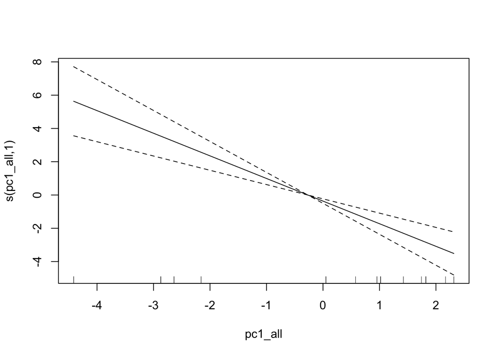

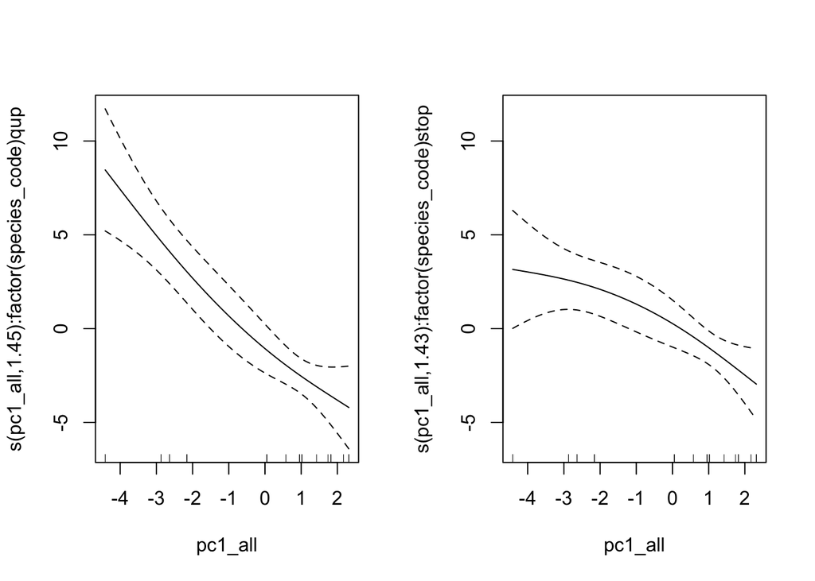

```
##
## Family: gaussian
## Link function: identity
##
## Formula:
## for_bites_mean ~ species_code + s(pc1_all, k = 3)
##
## Parametric coefficients:
##                  Estimate Std. Error t value Pr(>|t|)
## (Intercept)        9.7150     0.8228  11.808  3.4e-10 ***
## species_codestop  -3.2863     1.1170  -2.942  0.00837 **
## ---
## Signif. codes:  0 '***' 0.001 '**' 0.01 '*' 0.05 '.' 0.1 ' ' 1
##
## Approximate significance of smooth terms:
##            edf Ref.df     F p-value
## s(pc1_all)   1      1 29.45 1.9e-05 ***
## ---
## Signif. codes:  0 '***' 0.001 '**' 0.01 '*' 0.05 '.' 0.1 ' ' 1
##
## R-sq.(adj) =  0.644
##   Scale est. = 6.114     n = 22
```

```
##
## Family: gaussian
## Link function: identity
##
## Formula:
## for_bites_mean ~ species + s(pc1_all, by = factor(species_code),
##     k = 3)
##
## Parametric coefficients:
##                         Estimate Std. Error t value Pr(>|t|)
## (Intercept)               9.6417     0.7342  13.132 2.29e-10 ***
## speciesSparisoma viride  -3.2627     0.9922  -3.289  0.00431 **
## ---
## Signif. codes:  0 '***' 0.001 '**' 0.01 '*' 0.05 '.' 0.1 ' ' 1
##
## Approximate significance of smooth terms:
##                                       edf Ref.df      F  p-value
## s(pc1_all):factor(species_code)qup  1.455  1.455 18.901 7.54e-05 ***
## s(pc1_all):factor(species_code)stop 1.432  1.432  8.867  0.00987 **
## ---
## Signif. codes:  0 '***' 0.001 '**' 0.01 '*' 0.05 '.' 0.1 ' ' 1
##
## R-sq.(adj) =  0.703
##   Scale est. = 4.7889    n = 22
```

```
##
## Family: gaussian
## Link function: identity
##
## Formula:
## for_bites_mean ~ species_code + s(length_mean, k = 3) + s(pc1_all,
##     k = 3)
##
## Parametric coefficients:
##                  Estimate Std. Error t value Pr(>|t|)
## (Intercept)        9.7084     0.8201   11.84 6.28e-10 ***
## species_codestop  -3.2742     1.1137   -2.94  0.00876 **
## ---
## Signif. codes:  0 '***' 0.001 '**' 0.01 '*' 0.05 '.' 0.1 ' ' 1
##
## Approximate significance of smooth terms:
##                edf Ref.df      F p-value
## s(length_mean)   1      1  0.138   0.715
## s(pc1_all)       1      1 27.652 3.5e-05 ***
## ---
## Signif. codes:  0 '***' 0.001 '**' 0.01 '*' 0.05 '.' 0.1 ' ' 1
##
## R-sq.(adj) =  0.627
##   Scale est. = 6.0721    n = 22
```

## Supplement/optional

### Predator gape size

From Mumby et al.: Grouper *E. striatus*, gape width (G): G = -0.5998 + (0.167 × TL)

```r
g30_mum <- -0.5998 + (0.167 * 30) # 4
g40_mum <- -0.5998 + (0.167 * 40) # 6
```

From Goatley & Bellwood: Horizontal gape: G = -0.002 * SL + 6.421

```r
g30_goat <- -0.002 * 30 + 6.421
g40_goat <- -0.002 * 40 + 6.421
```

Dorsoventral height (Rakitin & Kramer 1996): S. viride: 15cm FL > 4.5cm body depth S. vetula: 15cm FL > 4.5cm body depth

### Loess plots for additional drivers?